[figure not shown]

# Deep Reinforcement Learning: DQN

```python
import numpy as np
import pandas as pd
import tensorflow as tf
import gym
from IPython import display
import matplotlib
import matplotlib.pyplot as plt
%matplotlib inline
```

## Introduction

Reinforcement Learning (RL) is a branch of machine learning concerned with taking sequences of actions. Sometimes it is called control and sometimes this is called decision making.

The two main objects in this setting are the *Agent* and the *Environment* and they are related as follows:

```
                 🎮
    ┌──────────action─────────┐
    │                         │
    │                         ↓
┌─────┐                 ┌───────────┐
│Agent│                 │Environment│
└─────┘                 └───────────┘
    ↑                         │
    └───observation, reward───┘
            👾         💯
```

At every time-step the Agent outputs an action and at the next time step the Environment returns an observation or the state of the system and a reward.

Usually RL is described in terms of this Agent interacting with a previously unknown Environment, trying to maximize the cumulative (or total) Reward.

### Applications

So what are some of the applications of RL? Well one area where it has been applied for a long time is in the area of operations research. Here RL is tasked with solving a variety of different problems that come up in business management.

One example is inventory management, where you have a store and you have to decide how much items you need to buy for your store, because if you run out, you will not be able to sell any more of this item and your customers will be upset. But if you buy too much you will lose money on the extra stuff. Your *observation* might be your current inventory level, the *action* will be how much of each item to buy and the *reward* is the profit.

Resource allocation or queueing problems are also well studied in this field, where you have a set of customers and you need to decide which ones to provide support to first.

Also, routing problems where you need to decide which truck to assign to which cargo. You can look at this as a sequential decision making problem which can be solved better by RL.

### Deep RL?

Now then, what is deep RL? Well in some sense it is Reinforcement learning using non-linear function approximators or the idea that you do not make much assumptions about the form of the objective for the agent. Instead we represent it as a deep neural netowork. We then use deep learning or more precisely stochastic gradient descent to find the optimal parameters of these function approximators.

The goal is that if we can come up with a system that can solve a variety of different environments, instead of being confined to a strict realms such as playing chess, then we are closer to to general AI.

[figure not shown]

And indeed, DeepMinds's DQN paper was featured on the Febuary 2015 cover of Nature, one of the most prestigious journals in science. In their paper, they applied the same model to 49 different Atari games and achieved superhuman performance in half of them. And that is the big premise of deep RL, to solve very difficult control problems in a variety of different environments.

Today we will implement the algorithm from this paper and show you its building blocks and concepts that you can use in your own environments, not just games. But we will stick to games and the first question is why games?

### Games?

Games are a great tool for Reinforcement learning research since they highlights many of the problems in a controlled environment for experimentation. Consider the game Breakout:

```python
display.YouTubeVideo('LO1cHqa8vUk')
```

[video not shown]

In this game you control a paddle at the bottom of the screen and have to bounce the ball back to clear all the bricks in the upper half of the screen. Each time you hit a brick, it disappears and your score increases – you get a reward.

Suppose your model gets as input these screen images. It would make sense to treat it as a classification problem – for each game screen you have to decide, whether you should move left, right or not do anything. A deep neural network could be given recordings of millions of images with the right move. But that is not how we learn. We don’t need somebody to tell us a million times which move to choose at each screen. We just need occasional feedback that we did the right thing and can then figure out everything else ourselves.

This is what RL is trying to solve. We have sparse and time-delayed labels: the score or reward. Based only on those rewards the agent has to learn to behave in the environment.

And this is very challenging: when you hit a brick and score a reward, it has nothing to do with the action you did just before you got the reward. The reward was set some time back when you positioned the paddle correctly and bounced off some wall. This is called the *credit assignment problem*: namely which of the proceeding actions was responsible for getting the reward and to what extent?

Once you have a strategy, should you stick with it or explore more? This is called the *explore-exploit dilemma* – should you exploit the known working strategy or explore other, possibly better strategies?

Finally, another problem is that of feedback. If we choose a method which makes a mistake which that ends up making the algorithm make more mistakes, you can end up with a feedback loop of failure, and its not obvious how these methods could ever work? But as we will see, not only do these methods work, they work very well, to super-human performance!

## OpenAI Gym

[OpenAI Gym](https://github.com/openai/gym) is a toolkit to develop reinforcement learning algorithms via Python. It more or less provides an interface for the agent to a number of different environment like Atari games for example. Thus it is compatible with any deep learning framework like TensorFlow or Pytorch.

### Basics

At its core, the OpenAI Gym API is very simple. You start by instantiating a specific environment via the `gym.make` function and then in the code below we render this environment for a 100 time-steps, where for each time step we take a random action by calling `step()` with a particular action:

[figure not shown]

```python
env = gym.make('Breakout-v4')
env.reset() # always reset after make

img = plt.imshow(env.render(mode='rgb_array')) # only call this once, only for jupyter

for _ in range(100):
    # env.render() instead of below if not in jupyter
    img.set_data(env.render(mode='rgb_array')) # just update the data
    plt.axis('off')
    display.display(plt.gcf())
    display.clear_output(wait=True)
    # end rendering

    # take a random action 🎲
    action = env.action_space.sample()
    env.step(action)
```

You could change the environment to something like Cart Pole (`CartPole-v1`) or Mountain Car (`MountainCar-v0`) or even another Atari game like Pacman (`MsPacman-v4`):

```python
# Your code here
```

If we ever want to do better than take random actions at each step, it'd probably be good to actually know what our actions are doing to the environment. The environment's `step()` function returns exactly what we need. In fact, `step()` returns four values:

- `observation` (object): an environment-specific object representing your observation of the environment. For example, pixel data from a camera, joint angles and joint velocities of a robot, or the board state in a board game.
- `reward` (float): amount of reward achieved by the previous action.
- `done` (boolean): a flag which tells us whether it's time to reset the environment again. Most (but not all) tasks are divided up into well-defined episodes, and `done` being `True` indicates the episode has terminated.
- `info` (dict): which contains diagnostic information useful for debugging. It can sometimes be useful for learning (for example, it might contain the raw probabilities behind the environment's last state change), but typically the learning algorithm will ignore this information.

Thus the best practice for a simulation is to do the following:

```
Episode done in 35 time steps
Total reward 35.0
```

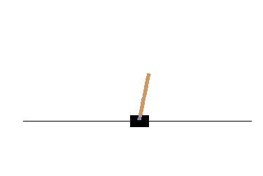

```python
env = gym.make('CartPole-v0')

for episode in range(3):
    observation = env.reset() # do not forget to reset
    total_reward = 0
    img = plt.imshow(env.render(mode='rgb_array')) # only call this once, only for jupyter

    for t in range(100):
        # env.render()
        img.set_data(env.render(mode='rgb_array')) # just update the data
        plt.axis('off')
        display.display(plt.gcf())
        display.clear_output(wait=True)

        action = env.action_space.sample() # still 🎲
        observation, reward, done, info = env.step(action)

        total_reward += reward

        if done:
            print("Episode done in {} time steps".format(t+1))
            print("Total reward {}".format(total_reward))
            break
```

Above we are running through three episodes and in each episode, we simulate a maximum of 100 time-steps. At each time-step we again sample a random action and then call `step()` to get the `observation`, `reward`, `done` and `info`. If `done` is `True`, we break out of our episode and start a new one.

### Space

In the cart pole example we were sampling random actions from the environment's action space. But what actually are those actions? Every environment comes with first-class `Space` objects that describe the valid actions via the `action_space` property and observations via the `observation_space` property.

For the cart pole case there are two discrete actions a `0` or a `1`:

```python
env = gym.make('CartPole-v0')
print(env.action_space)
```

```
[2017-12-08 11:46:21,285] Making new env: CartPole-v0
```

```
Discrete(2)
```

Spaces can also be continous. The observations are represented by the `Box` space which for the cart pole is an array of 4 numbers:

```python
print(env.observation_space)
```

```
Box(4,)
```

```python
print(observation)
```

```
[ 0.03772693 -0.2887199   0.23645675  1.47769185]
```

Thus by using the `Space` environment introspection methods we can figure out the size of the observation:

```python
env.observation_space.shape
```

```
(4,)
```

And we can figure out the number of actions that our agent can do:

```python
env.action_space.n
```

```
2
```

This way we can design our algorithms to be general enough that they can take any environment as input and output the appropriate number of actions and not really care too much about the actual values of the observations. We will let the neural network figure out how best to deal with the incoming data by itself.

### Wrappers

The final OpenAI Gym concept is that of wrappers. We will need to, many times, override the default observations, rewards or actions of a particular environment. We will achieve this by using `Wrappers`. For example the observations from the Atari games are color images and we can imagine if the color is not important for the agent to use, we can write an `ObservationWrapper` object that converts the color image to grayscale. This way we can reduce the size of our input by a factor of 3.

Similarly one can define an `RewardWrapper` or an `ActionWrapper` to override the default rewards or Actions. Try now to think about the types of wrappers we will need for the Atari games? The final version of our algorithm will have about 5 or so wrappers!

So as a hint, we saw for Atari, we can convert the observations to grayscale. We could also stack a number of time frames together (say 4 frames) as our observation. This way the neural network will be able to judge movement and for example in the breakout game the neural network will be able to learn which way to move the paddle, much easily than if it were a single frame. We could do something more and calculate the maximum of say 4 frames and set that as our observation.

We could also for example standardize the rewards to be between say -1 and 1. This as we will see will help too, and we will do this via a wrapper.

Finally for some games we will want to initially sample the states randomly for some time and then start taking real actions. For other environment we would set the end of the episode when all the lives are finished and not when a single life dies. We will achieve all this through wrappers.

As an example here is a simple Rewards wrapper:

```python
class ClippedRewardsWrapper(gym.RewardWrapper):
    def _reward(self, reward):
        """Change all the positive rewards to 1, negative to -1 and keep zero."""
        return np.sign(reward)
```

Now to use it we can wrap our environment to through this wrapper:

```python
env = gym.make('CartPole-v0')
env = ClippedRewardsWrapper(env)
env.reset()
```

```
[2017-12-08 11:52:31,849] Making new env: CartPole-v0
```

```
array([-0.02497014,  0.03137364,  0.00797788, -0.03666526])
```

```python
_, reward, _, _ = env.step(env.action_space.sample())
print(reward)
```

```
1.0
```

If we want the original unwrapped environment we can just call `.unwrapped` on the environment object:

```python
_, reward, _, _ = env.unwrapped.step(env.action_space.sample())
print(reward)
```

```
1.0
```

## Mathematical Formulation

In order to solve the RL problem we will now frame it into a mathematical framework. So in the episodic setting, the agent's experience is broken up into a series of episodes, which are a sequence of states, actions and rewards.

In the fully observed setting each episode begins by sampling an initial state of the environment, from the state distribution: $$s_0 \sim \mu(s_0)$$

Then for each time step the agent chooses an action, sampled from the agent's set of actions given by $\pi_\theta$ called the *policy*:

$$ a_0 \sim \pi_\theta(a_0|s_0)$$

Then the environment generates the next state and reward, according to the transition probability: $$s_1, r_0 \sim P(s_1, r_0 | s_0, a_0)$$

And we repeat this: $$a_1 \sim \pi_\theta(a_1|s_1),$$ $$s_2, r_1 \sim P(s_2, r_1 | s_1, a_1), \ldots$$

The episode ends when a terminal state at time $T$ is reached: $$a_{T-1} \sim \pi_\theta(a_{T-1}|s_{T-1}),$$ $$s_T, r_{T-1} \sim P(s_T, r_{T-1} | s_{T-1}, a_{T-1}).$$

The goal thus of RL is to find a policy that optimizes the expected discounted reward, where the discount factor is a $\gamma \in [0,1)$:

$$\mathbb{E}_{\tau}[R_0 | \pi_{\theta}]$$ where $$R_0 = r_0 + \gamma r_1 + \gamma^2 r_2 + \cdots + \gamma^{T-1} r_{T-1}$$

and the expectation is taken over the trajectory $\tau$ defined as the sequence of states, actions, rewards: $(s_0, a_0, r_0, s_1, a_1, r_1, \ldots, s_T)$.

### Value Functions

The fundamental quantity in this setting is the state-action value function:

$$Q^{\pi}(s_t, a_t) = \mathbb{E}_{\pi}[r_{t+1} + \gamma r_{t+2} + \gamma^2 r_{t+3}\cdots | s_t, a_t]$$

which represents the expected discounted sum of rewards conditioned on some some initial state $s_t$ and action $a_t$, if we act under the policy $\pi_\theta$ from that point onwards. The $Q$ function tells us how good this state-action pair is under our current policy. Intuitively, the $Q$ function measures the value, or mean reward, when choosing a particular action in a particular state.

The state value function:

$$V^{\pi}(s_t) = \mathbb{E}_{\pi}[r_{t+1} + \gamma r_{t+2} + \gamma^2 r_{t+3}\cdots | s_t] = \mathbb{E}_{a_t \sim \pi}[Q^{\pi}(s_t, a_t)]$$

is defined as the expected discounted sum of rewards conditioned at some state and it tell us how good this state is, in terms of what the expected reward is for that state on average under the policy $\pi_\theta$. Intuitively, the value function $V$ measures the how good, on average, it is to be in a particular state $s_t$.

Lastly we have the advantage function:

$$A^{\pi}(s_t, a_t) = Q^{\pi}(s_t, a_t) - V^{\pi}(s_t)$$

the difference between the $Q$ function and the value function, meaning how much better is that action than what the policy would have done. This way we can get a relative measure of the importance of each action.

### Dynamic Programming

Broadly speaking, the dynamical programming apporach to solving RL problems will explicitly store the $Q$-function instead of the policy and update them using what are called Bellman equations. The Bellman equations are a consistency equation which has to be satisfied by value functions. In particular for the $Q^\pi$ function we must have:

$$\begin{align} Q^{\pi}(s_0, a_0) & = \mathbb{E}_{\pi}[r_{0} + \gamma r_{1} + \gamma^2 r_{2}\cdots | s_0, a_0] \\ &= \mathbb{E}_{s_{1} \sim P(s_{1} | s_0, a_0)}[r_{0} + \gamma \mathbb{E}_{a_1 \sim \pi}[Q^{\pi}(s_1, a_1)]] \end{align}$$

which is saying that the expected sum of rewards should be the sum of the first rewards and the expected sum of rewards after the first time step. We can also generalize this to $k$ time steps:

$$\begin{align} Q^{\pi}(s_0, a_0) & = \mathbb{E}_{s_1, a_1 | s_0, a_0} [r_0 + \gamma Q^{\pi}(s_1, a_1)] \\ &= \mathbb{E}_{s_1, a_1, s_2, a_2 | s_0, a_0} [ r_0 + \gamma r_1 + \gamma^2 Q^{\pi}(s_2, a_2)] \\ &=\mathbb{E}_{s_1, a_1, \ldots, s_k, a_k | s_0, a_0}[r_0 + \cdots + \gamma^{k-1} r_{k-1} + \gamma^{k} Q^{\pi}(s_k, a_k)] \end{align}$$

where we write the $k$ sums explicitly and cap it off by the $Q$ function.

### Bellman Backups

Now the most important concept is that of the Bellman Backup. We do not know what the $Q^\pi$ is. Let us assume we have some other $Q$ function. We can then define the Bellman Backup operator acting on an arbitrary $Q$ functions as:

$$[B^\pi Q](s_0, a_0) = \mathbb{E}_{s_{1} \sim P(s_{1} | s_0, a_0)}[r_{0} + \gamma \mathbb{E}_{a_1 \sim \pi}[Q(s_1, a_1)]]$$

where we are mapping a $Q$ function to another $Q$ function via this definition which is nothing more than the right-hand side of the Bellman equation. Now because of the discount factor $\gamma$ this operation is a contraction and by Banach's theorem has a fixed point which by the Bellman equation is:

$$B^\pi Q^\pi = Q ^\pi.$$

And also more nicely, if we keep applying $B^\pi$ to an initial $Q$, the series will converge to $Q^\pi$!

### $Q^{*}$

Now the $Q^\pi$ was still with respect to some fixed policy $\pi$. We will now define $Q^{*}$ to involve the optimal policy $\pi^{*}$ as:

$$Q^{*}(s, a) = \max_{\pi} Q^{\pi}(s,a)$$

which is the $Q$ function of the optimal policy. It is the pointwise maximum of all the policies over the $Q$ function at each state-action pair. So the $Q$ function returns the expected return if you take the given action in a particular state, so obviously the optimal policy should take the action which has the best expected return for a particular state. That is why we can define the optimal policy as

$$ \pi^{*}(s) = \underset{a}{\mathrm{argmax}}\, Q^{*}(s, a).$$

Now in the Bellman equation we can take the expectation over actions and replace it by what the optimal policy is going to do:

$$Q^{*}(s_0, a_0) = \mathbb{E}_{s_{1} \sim P(s_{1} | s_0, a_0)}[r_{0} + \gamma \max_{a_1} Q^{*}(s_1, a_1)]$$

which is just going to take the argmax of the optimal $Q$ function. This gives us a Bellman equation which the optimal policy $Q^{*}$ satisfies.

Now we can also define the corresponding Bellman backup operator:

$$[BQ](s_0, a_0) = \mathbb{E}_{s_{1} \sim P(s_{1} | s_0, a_0)}[r_{0} + \gamma \max_{a_1} Q(s_1, a_1)]$$

where again the $Q^*$ is a fixed point of this operator and again if we apply this operator repeatedly to an arbitrary $Q$ function it converges to $Q^*$ which is the optimal $Q$ function.

## Classical Algorithms

Based on these ideas we have two classical algorithms for exactly solving the RL problem via the dynamical programming approach. And then in the late 90's and mid 2000's we have neural networks coming in. So let us recap.

### Value Iteration

In the value iteration we initialize an arbitrary $Q$ and then repeatidly do $Q \leftarrow BQ$ until convergence.

### Policy Iteration

In Policy iteration we initialize some policy $\pi$ and then first compute $Q^\pi$, which we can solve as a linear system of equations or if the space is too large, we can approximate it by doing $k$ Bellman backups. Then we can select the greedy policy in the sense that our new policy will select the action which maximizes the expected sum of rewards for some given state.

Note that this and the value iteration algorithms work if we have full access to the states of the enviornment or know the full table of transition probabilities. In practice we will not know any of these probability distributions.

### Sampling based (1994)

Remarkably this [paper](https://papers.nips.cc/paper/764-convergence-of-stochastic-iterative-dynamic-programming-algorithms.pdf) from 1994 showed that even if we do not know the transition probabilities, it can either be estimated from data or you can get it by interacting with the environment.

Recall the Bellman backup for $Q^*$ and for $Q^\pi$. Both of these we have some quantity inside the expectation and we can compute unbiased estimators of them using a single sample, meaning if we sampled some data from our system using any policy then these terms are unbiased.

So we can do an approximate version of the Bellman backup which is unbiased:

$$[\hat{BQ}](s_0, a_0) = r_{0} + \gamma \max_{a_1} Q(s_1, a_1)$$

and even with this noise it can be shown, if we choose our step sizes appropriately, with the right schedule we will converge to $Q^*$.

### Functional approximators (2005)

So now we can start coming up with RL algorithms that access the environment via sampling and defining functional approximators. We did not mention what the $Q$ function is, accept that its a function of states and actions, but now we can have neural network $Q$ functions!

And this [paper](http://ml.informatik.uni-freiburg.de/_media/publications/rieecml05.pdf) from 2005 did exactly that. We parametrizs the $Q$ function with the weights of a neural network given by $\theta$. Here we cannot do any Bellman backups, because it does not make sense in the neural network setting since we are not setting the values of the neural network output, the best we can do is encourage the network to have some output values.

So what we do instead is that we setup a least-squares problem, by having this quadratic objective which says that the $Q$ function (or neural network) should be approximately equal to the backed-up value, and then we minimize this via SGD.

The full algorithm turns out to be:

- Parametrize $Q$ function with neural network weights $Q_\theta$
- Instead of $Q \leftarrow \hat{BQ}$ do:
  1. Initialize $\theta^{(0)}$
  2. For $n = 1, 2, \ldots$ do:
     - Sample trajectory using $\pi^{(n)}$
     - $\theta^{(n)} = \min_{\theta} \sum_{t} \| Q_{\theta^{(n)}}(s_t, a_t) - \hat{BQ}_{\theta^{(n-1)}}(s_t, a_t) \|^2$

## DQN (2013)

Finally we are ready to introduce the Deep Q-Network (DQN) algorithm, which has caused a lot of buzz around DRL, from 2013. It is more or less an online version of the neural fitted value iteration paper from 2005, which we talked about above, with a few very useful tweaks.

The first addition is the use of a rolling history of the past data via a *replay pool*. This has the advantage that each step of the experience is potentially used in many weight updates which allows for data efficiency. Also learning from consecutive samples is inefficient due to strong correlations between the samples, and so randomizing these samples breaks the correlations and reduces the variance of the updates.

There is another reason why replay pools are important, and this has to do with the nature of the algorithm. The current parameters of the neural network determine the next data sample that the neural network then trains on. So for example, if the maximizing action in a game is to move left then the training samples will be dominated by samples from the left-hand side; if the maximizing action then switches to the right then the training distribution will also switch. This means, that unwanted feedback loops can occure and one might get stuck in a poor local minimum or even diverge when training!

By using the replay pool the behavior distribution is averaged over many of its previous states, smoothing out learning and avoiding oscillations.

The other big idea is the use of a *target network*, to represent the old $Q$ function, which will be used to compute the loss for every action during training. Why not use a single network? Well the issue is that at each step of training, the $Q$ function's values change and then the value estimates can easily spiral out of control. The network can become destabilized by falling into feedback loops between the target and the estimated $Q$ values. So to mitigate this, the target network's weights are fixed and are changed only periodically compared to the primary $Q$ function network. In this way training can proceed in a more stable manner.

So let us implement this for the Atari games!

### Replay Buffer

```python
import random

class ReplayBuffer(object):
    def __init__(self, size):
        """Create a Replay buffer.

        Parameters
        ----------
        size: int
            Max number of transitions to store in the buffer. When the buffer
            overflows the old memories are dropped.
        """
        self._storage = []
        self._maxsize = size
        self._next_idx = 0

    def __len__(self):
        return len(self._storage)

    def add(self, obs_t, action, reward, obs_tp1, done):
        data = (obs_t, action, reward, obs_tp1, done)

        if self._next_idx >= len(self._storage):
            self._storage.append(data)
        else:
            self._storage[self._next_idx] = data
        self._next_idx = (self._next_idx + 1) % self._maxsize

    def _encode_sample(self, idxes):
        obses_t, actions, rewards, obses_tp1, dones = [], [], [], [], []
        for i in idxes:
            data = self._storage[i]
            obs_t, action, reward, obs_tp1, done = data
            obses_t.append(np.array(obs_t, copy=False))
            actions.append(np.array(action, copy=False))
            rewards.append(reward)
            obses_tp1.append(np.array(obs_tp1, copy=False))
            dones.append(done)
        return np.array(obses_t), np.array(actions), np.array(rewards), np.array(obses_tp1), np.array(dones)

    def sample(self, batch_size):
        """Sample a batch of experiences.

        Parameters
        ----------
        batch_size: int
            How many transitions to sample.

        Returns
        -------
        obs_batch: np.array
            batch of observations
        act_batch: np.array
            batch of actions executed given obs_batch
        rew_batch: np.array
            rewards received as results of executing act_batch
        next_obs_batch: np.array
            next set of observations seen after executing act_batch
        done_mask: np.array
            done_mask[i] = 1 if executing act_batch[i] resulted in
            the end of an episode and 0 otherwise.
        """
        idxes = [random.randint(0, len(self._storage) - 1) for _ in range(batch_size)]
        return self._encode_sample(idxes)
```

### Atari Wrappers

```python
class EpisodicLifeEnv(gym.Wrapper):
    def __init__(self, env=None):
        """Make end-of-life == end-of-episode, but only reset on true game over.
        Done by DeepMind for the DQN and co. since it helps value estimation.
        """
        super(EpisodicLifeEnv, self).__init__(env)
        self.lives = 0
        self.was_real_done = True
        self.was_real_reset = False

    def _step(self, action):
        obs, reward, done, info = self.env.step(action)
        self.was_real_done = done
        # check current lives, make loss of life terminal,
        # then update lives to handle bonus lives
        lives = self.env.unwrapped.ale.lives()
        if lives < self.lives and lives > 0:
            # for Qbert somtimes we stay in lives == 0 condtion for a few frames
            # so its important to keep lives > 0, so that we only reset once
            # the environment advertises done.
            done = True
        self.lives = lives
        return obs, reward, done, info

    def _reset(self):
        """Reset only when lives are exhausted.
        This way all states are still reachable even though lives are episodic,
        and the learner need not know about any of this behind-the-scenes.
        """
        if self.was_real_done:
            obs = self.env.reset()
            self.was_real_reset = True
        else:
            # no-op step to advance from terminal/lost life state
            obs, _, _, _ = self.env.step(0)
            self.was_real_reset = False
        self.lives = self.env.unwrapped.ale.lives()
        return obs
```

```python
class NoopResetEnv(gym.Wrapper):
    def __init__(self, env=None, noop_max=30):
        """Sample initial states by taking random number of no-ops on reset.
        No-op is assumed to be action 0.
        """
        super(NoopResetEnv, self).__init__(env)
        self.noop_max = noop_max
        self.override_num_noops = None
        assert env.unwrapped.get_action_meanings()[0] == 'NOOP'

    def _reset(self):
        """ Do no-op action for a number of steps in [1, noop_max]."""
        self.env.reset()
        if self.override_num_noops is not None:
            noops = self.override_num_noops
        else:
            noops = np.random.randint(1, self.noop_max + 1)
        assert noops > 0
        obs = None
        for _ in range(noops):
            obs, _, done, _ = self.env.step(0)
            if done:
                obs = self.env.reset()
        return obs
```

```python
from collections import deque

class MaxAndSkipEnv(gym.Wrapper):
    def __init__(self, env=None, skip=4):
        """Return only every `skip`-th frame"""
        super(MaxAndSkipEnv, self).__init__(env)
        # most recent raw observations (for max pooling across time steps)
        self._obs_buffer = deque(maxlen=2)
        self._skip = skip

    def _step(self, action):
        total_reward = 0.0
        done = None
        for _ in range(self._skip):
            obs, reward, done, info = self.env.step(action)
            self._obs_buffer.append(obs)
            total_reward += reward
            if done:
                break

        max_frame = np.max(np.stack(self._obs_buffer), axis=0)

        return max_frame, total_reward, done, info

    def _reset(self):
        """Clear past frame buffer and init. to first obs. from inner env."""
        self._obs_buffer.clear()
        obs = self.env.reset()
        self._obs_buffer.append(obs)
        return obs
```

```python
from gym import spaces
from PIL import Image

class ProcessFrame84(gym.ObservationWrapper):
    def __init__(self, env=None):
        super(ProcessFrame84, self).__init__(env)
        self.observation_space = spaces.Box(low=0, high=255, shape=(84, 84, 1))

    def _observation(self, obs):
        return ProcessFrame84.process(obs)

    @staticmethod
    def process(frame):
        if frame.size == 210 * 160 * 3:
            img = np.reshape(frame, [210, 160, 3])
        elif frame.size == 250 * 160 * 3:
            img = np.reshape(frame, [250, 160, 3])
        else:
            assert False, "Unknown resolution."
        img = Image.fromarray(img).convert('L')

        resized_screen = np.asarray(img.resize((84, 110), Image.ANTIALIAS))
        x_t = resized_screen[18:102, :]
        x_t = np.reshape(x_t, [84, 84, 1])
        return x_t.astype(np.uint8)
```

```python
class FrameStack(object):
    def __init__(self, frames):
        """Return a stack of the frames as an object.
        This object should only be converted to numpy array before being
        passed to the model."""
        self._frames = frames

    def __array__(self, dtype=None):
        out = np.concatenate(self._frames, axis=2)
        if dtype is not None:
            out = out.astype(dtype)
        return out


class LazyFrames(gym.Wrapper):
    def __init__(self, env, k=4, rtol=1.0):
        """This wrapper ensures that common frames between the observations are
        only stored once. It exists purely to optimize memory usage which can
        be huge for DQN's 1M frames replay buffers."""
        super(LazyFrames, self).__init__(env)
        self.k = k
        self.rtol = rtol
        self.frames = deque([], maxlen=self.k)
        shp = env.observation_space.shape
        self.observation_space = spaces.Box(low=0, high=255, shape=(shp[0], shp[1], shp[2] * self.k))

    def _reset(self):
        ob = self.env.reset()
        for _ in range(self.k):
            self.frames.append(ob)
        return self._get_ob()

    def _step(self, action):
        ob, reward, done, info = self.env.step(action)
        if not np.allclose(ob, self.frames[-1], rtol=self.rtol):
            self.frames.append(ob)
        return self._get_ob(), reward, done, info

    def _get_ob(self):
        assert len(self.frames) == self.k
        return FrameStack(list(self.frames))
```

```python
class ClippedRewardsWrapper(gym.RewardWrapper):
    def _reward(self, reward):
        """Change all the positive rewards to 1, negative to -1 and keep zero."""
        return np.sign(reward)
```

```python
import time

class SimpleMonitor(gym.Wrapper):
    def __init__(self, env):
        """Adds two qunatities to info returned by every step:
            num_steps: int
                Number of steps takes so far
            rewards: [float]
                All the cumulative rewards for the episodes completed so far.
        """
        super(SimpleMonitor, self).__init__(env)
        # current episode state
        self._current_reward = None
        self._num_steps = None
        # temporary monitor state that we do not save
        self._time_offset = None
        self._total_steps = None
        # monitor state
        self._episode_rewards = []
        self._episode_lengths = []
        self._episode_end_times = []

    def _reset(self):
        obs = self.env.reset()
        # recompute temporary state if needed
        if self._time_offset is None:
            self._time_offset = time.time()
            if len(self._episode_end_times) > 0:
                self._time_offset -= self._episode_end_times[-1]
        if self._total_steps is None:
            self._total_steps = sum(self._episode_lengths)
        # update monitor state
        if self._current_reward is not None:
            self._episode_rewards.append(self._current_reward)
            self._episode_lengths.append(self._num_steps)
            self._episode_end_times.append(time.time() - self._time_offset)
        # reset episode state
        self._current_reward = 0
        self._num_steps = 0

        return obs

    def _step(self, action):
        obs, rew, done, info = self.env.step(action)
        self._current_reward += rew
        self._num_steps += 1
        self._total_steps += 1
        info['steps'] = self._total_steps
        info['rewards'] = self._episode_rewards
        return (obs, rew, done, info)

    def get_state(self):
        return {
            'env_id': self.env.unwrapped.spec.id,
            'episode_data': {
                'episode_rewards': self._episode_rewards,
                'episode_lengths': self._episode_lengths,
                'episode_end_times': self._episode_end_times,
                'initial_reset_time': 0,
            }
        }

    def set_state(self, state):
        assert state['env_id'] == self.env.unwrapped.spec.id
        ed = state['episode_data']
        self._episode_rewards = ed['episode_rewards']
        self._episode_lengths = ed['episode_lengths']
        self._episode_end_times = ed['episode_end_times']
```

```python
def wrap_dqn(env):
    env = EpisodicLifeEnv(env)
    env = NoopResetEnv(env, noop_max=30)
    env = MaxAndSkipEnv(env, skip=4)
    env = ProcessFrame84(env)
    env = LazyFrames(env, k=4, rtol=1.0)
    env = ClippedRewardsWrapper(env)
    return env
```

```python
def make_env(game_name='Breakout'):
    env = gym.make(game_name + "NoFrameskip-v4")
    monitored_env = SimpleMonitor(env)
    env = wrap_dqn(monitored_env)
    return env, monitored_env
```

### Saving

```python
def load_state(fname):
    saver = tf.train.Saver()
    saver.restore(tf.get_default_session(), fname)
```

```python
import os

def save_state(fname):
    os.makedirs(os.path.dirname(fname))
    saver = tf.train.Saver()
    saver.save(tf.get_default_session(), fname)
```

```python
import joblib

def save_model(savedir, state):
    if savedir is None:
        return
    start_time = time.time()
    model_dir = "model-{}".format(state["num_iters"])

    save_state(os.path.join(savedir, model_dir, "saved"))

    joblib.dump(state, os.path.join(savedir, 'training_state.pkl.zip'), compress=9)
    joblib.dump(state["monitor_state"], os.path.join(savedir, 'monitor_state.pkl'))
```

```python
def load_model(savedir):
    if savedir is None:
        return
    state_path = os.path.join(os.path.join(savedir, 'training_state.pkl.zip'))
    if os.path.exists(state_path):
        state = joblib.load(state_path)
        model_dir = "model-{}".format(state["num_iters"])

        load_state(os.path.join(savedir, model_dir, "saved"))
        return state
```

### Tensorflow Helpers

```python
class TfInput(object):
    def __init__(self, name="(unnamed)"):
        """Generalized Tensorflow placeholder. The main differences are:
            - possibly uses multiple placeholders internally and returns multiple values
            - can apply light postprocessing to the value fed to placeholder.
        """
        self.name = name

    def get(self):
        """Return the tf variable(s) representing the possibly postprocessed value
        of placeholder(s).
        """
        raise NotImplemented()

    def make_feed_dict(data):
        """Given data input it to the placeholder(s)."""
        raise NotImplemented()
```

```python
class PlacholderTfInput(TfInput):
    def __init__(self, placeholder):
        """Wrapper for regular tensorflow placeholder."""
        super(PlacholderTfInput, self).__init__(placeholder.name)
        self._placeholder = placeholder

    def get(self):
        return self._placeholder

    def make_feed_dict(self, data):
        return {self._placeholder: data}
```

```python
class Uint8Input(PlacholderTfInput):
    def __init__(self, shape, name=None):
        """Takes input in uint8 format which is cast to float32 and divided by 255
        before passing it to the model.

        On GPU this ensures lower data transfer times.

        Parameters
        ----------
        shape: [int]
            shape of the tensor.
        name: str
            name of the underlying placeholder
        """
        super(Uint8Input, self).__init__(tf.placeholder(tf.uint8, [None] + list(shape), name=name))
        self._shape = shape
        self._output = tf.cast(super(Uint8Input, self).get(), tf.float32) / 255.0

    def get(self):
        return self._output
```

```python
class _Function(object):
    def __init__(self, inputs, outputs, updates, givens, check_nan=False):
        for inpt in inputs:
            if not issubclass(type(inpt), TfInput):
                assert len(inpt.op.inputs) == 0, "inputs should all be placeholders of baselines.common.TfInput"
        self.inputs = inputs
        updates = updates or []
        self.update_group = tf.group(*updates)
        self.outputs_update = list(outputs) + [self.update_group]
        self.givens = {} if givens is None else givens
        self.check_nan = check_nan

    def _feed_input(self, feed_dict, inpt, value):
        if issubclass(type(inpt), TfInput):
            feed_dict.update(inpt.make_feed_dict(value))
        elif type(inpt) is tf.Tensor and len(inpt.op.inputs) == 0:
            feed_dict[inpt] = value

    def __call__(self, *args, **kwargs):
        assert len(args) <= len(self.inputs), "Too many arguments provided"
        feed_dict = {}
        # Update the args
        for inpt, value in zip(self.inputs, args):
            self._feed_input(feed_dict, inpt, value)
        # Update the kwargs
        kwargs_passed_inpt_names = set()
        for inpt in self.inputs[len(args):]:
            inpt_name = inpt.name.split(':')[0]
            inpt_name = inpt_name.split('/')[-1]
            assert inpt_name not in kwargs_passed_inpt_names, \
                "this function has two arguments with the same name \"{}\", so kwargs cannot be used.".format(inpt_name)
            if inpt_name in kwargs:
                kwargs_passed_inpt_names.add(inpt_name)
                self._feed_input(feed_dict, inpt, kwargs.pop(inpt_name))
            else:
                assert inpt in self.givens, "Missing argument " + inpt_name
        assert len(kwargs) == 0, "Function got extra arguments " + str(list(kwargs.keys()))
        # Update feed dict with givens.
        for inpt in self.givens:
            feed_dict[inpt] = feed_dict.get(inpt, self.givens[inpt])
        results = tf.get_default_session().run(self.outputs_update, feed_dict=feed_dict)[:-1]
        if self.check_nan:
            if any(np.isnan(r).any() for r in results):
                raise RuntimeError("Nan detected")
        return results
```

```python
from collections import OrderedDict

def function(inputs, outputs, updates=None, givens=None):
    if isinstance(outputs, list):
        return _Function(inputs, outputs, updates, givens=givens)
    elif isinstance(outputs, (dict, OrderedDict)):
        f = _Function(inputs, outputs.values(), updates, givens=givens)
        return lambda *args, **kwargs: type(outputs)(zip(outputs.keys(), f(*args, **kwargs)))
    else:
        f = _Function(inputs, [outputs], updates, givens=givens)
        return lambda *args, **kwargs: f(*args, **kwargs)[0]
```

```python
def scope_vars(scope, trainable_only=False):
    return tf.get_collection(
        tf.GraphKeys.TRAINABLE_VARIABLES if trainable_only else tf.GraphKeys.GLOBAL_VARIABLES,
        scope=scope if isinstance(scope, str) else scope.name)
```

```python
def scope_name():
    return tf.get_variable_scope().name
```

```python
def absolute_scope_name(relative_scope_name):
    return scope_name() + "/" + relative_scope_name
```

### Linear Noise Schedule

We will initially start with a noisy policy, which will explore more and slowly decay the noise via schedule helpers which we define below:

```python
def linear_interpolation(l, r, alpha):
    return l + alpha * (r - l)
```

```python
class PiecewiseSchedule(object):
    def __init__(self, endpoints, interpolation=linear_interpolation, outside_value=None):
        idxes = [e[0] for e in endpoints]
        assert idxes == sorted(idxes)
        self._interpolation = interpolation
        self._outside_value = outside_value
        self._endpoints = endpoints

    def value(self, t):
        for (l_t, l), (r_t, r) in zip(self._endpoints[:-1], self._endpoints[1:]):
            if l_t <= t and t < r_t:
                alpha = float(t - l_t) / (r_t - l_t)
                return self._interpolation(l, r, alpha)

        # t does not belong to any of the pieces, so doom.
        assert self._outside_value is not None
        return self._outside_value
```

### Model (Policy)

```python
import tensorflow.contrib.layers as layers

def model(img_in, num_actions, scope, reuse=False):
    with tf.variable_scope(scope, reuse=reuse):
        out = img_in
        with tf.variable_scope("convnet"):
            out = layers.convolution2d(out, num_outputs=32, kernel_size=8, stride=4, activation_fn=tf.nn.relu)
            out = layers.convolution2d(out, num_outputs=64, kernel_size=4, stride=2, activation_fn=tf.nn.relu)
            out = layers.convolution2d(out, num_outputs=64, kernel_size=3, stride=1, activation_fn=tf.nn.relu)
        out = layers.flatten(out)

        with tf.variable_scope("action_value"):
            out = layers.fully_connected(out, num_outputs=512, activation_fn=tf.nn.relu)
            out = layers.fully_connected(out, num_outputs=num_actions, activation_fn=None)

        return out
```

```python
# Function to choose an action given an obs
def build_act(make_obs_ph, q_func, num_actions, scope="deepq", reuse=None):
    with tf.variable_scope(scope, reuse=reuse):
        observations_ph = make_obs_ph("observation")
        stochastic_ph = tf.placeholder(tf.bool, (), name="stochastic")
        update_eps_ph = tf.placeholder(tf.float32, (), name="update_eps")

        eps = tf.get_variable("eps", (), initializer=tf.constant_initializer(0))

        q_values = q_func(observations_ph.get(), num_actions, scope="q_func")
        deterministic_actions = tf.argmax(q_values, axis=1)

        batch_size = tf.shape(observations_ph.get())[0]
        random_actions = tf.random_uniform(tf.stack([batch_size]), minval=0, maxval=num_actions, dtype=tf.int64)
        chose_random = tf.random_uniform(tf.stack([batch_size]), minval=0, maxval=1, dtype=tf.float32) < eps
        stochastic_actions = tf.where(chose_random, random_actions, deterministic_actions)

        output_actions = tf.cond(stochastic_ph, lambda: stochastic_actions, lambda: deterministic_actions)
        update_eps_expr = eps.assign(tf.cond(update_eps_ph >= 0, lambda: update_eps_ph, lambda: eps))


        act = function(inputs=[observations_ph, stochastic_ph, update_eps_ph],
                       outputs=output_actions,
                       givens={update_eps_ph: -1.0, stochastic_ph: True},
                       updates=[update_eps_expr])
        return act
```

```python
# Function that takes a transition and optimizes Bellman equation's error
def build_train(make_obs_ph, q_func, num_actions, optimizer, gamma=1.0, scope="deepq", reuse=None):
    act_f = build_act(make_obs_ph, q_func, num_actions, scope=scope, reuse=reuse)

    with tf.variable_scope(scope, reuse=reuse):
        obs_t_input = make_obs_ph("obs_t")
        act_t_ph = tf.placeholder(tf.int32, [None], name="action")
        rew_t_ph = tf.placeholder(tf.float32, [None], name="reward")
        obs_tp1_input = make_obs_ph("obs_tp1")
        done_mask_ph = tf.placeholder(tf.float32, [None], name="done")

        # q network evaluation
        q_t = q_func(obs_t_input.get(), num_actions, scope="q_func", reuse=True)
        q_func_vars = scope_vars(absolute_scope_name("q_func"))

        # q scores for actions which we know were selected in the given state.
        q_t_selected = tf.reduce_sum(q_t * tf.one_hot(act_t_ph, num_actions), 1)

        # target q network evaluation
        q_tp1 = q_func(obs_tp1_input.get(), num_actions, scope="target_q_func")
        target_q_func_vars = scope_vars(absolute_scope_name("target_q_func"))

        # compute estimate of best possible value starting from state at t + 1
        q_tp1_best = tf.reduce_max(q_tp1, 1)
        q_tp1_best_masked = (1.0 - done_mask_ph) * q_tp1_best

        # compute RHS of bellman equation
        q_t_selected_target = rew_t_ph + gamma * q_tp1_best_masked

        # compute the error (potentially clipped)
        td_error = q_t_selected - tf.stop_gradient(q_t_selected_target)
        loss = tf.losses.huber_loss(q_t_selected, tf.stop_gradient(q_t_selected_target))
        optimize_expr = optimizer.minimize(loss, var_list=q_func_vars)

        # update_target will be called periodically to copy Q network to target Q network
        update_target_expr = []
        for var, var_target in zip(sorted(q_func_vars, key=lambda v: v.name),
                                   sorted(target_q_func_vars, key=lambda v: v.name)):
            update_target_expr.append(var_target.assign(var))
        update_target_expr = tf.group(*update_target_expr)
        update_target = function([], [], updates=[update_target_expr])

        # create train function
        train = function(
            inputs=[obs_t_input,
                act_t_ph,
                rew_t_ph,
                obs_tp1_input,
                done_mask_ph],
            outputs=td_error, updates=[optimize_expr])

        q_values = function([obs_t_input], q_t)

        return act_f, train, update_target, {'q_values': q_values}
```

### Training

```python
hparam = tf.contrib.training.HParams(
    env = "Breakout",
    lr = 1e-4,
    num_steps = int(1e5),
    replay_buffer_size = int(1e4),
    batch_size = 32,

    target_update_freq = 1000,
    learning_freq = 4,

    discount = 0.99,

    save_dir = "models",
    save_freq = 5000
)
```

```python
env, monitored_env = make_env(hparam.env)
```

```
[2017-12-08 12:11:48,286] Making new env: BreakoutNoFrameskip-v4
```

```python
tf.reset_default_graph()

with tf.Session() as sess:
    act, train, update_target, _ = build_train(
        make_obs_ph=lambda name: Uint8Input(env.observation_space.shape, name=name),
        q_func=model,
        num_actions=env.action_space.n,
        optimizer=tf.train.AdamOptimizer(learning_rate=hparam.lr, epsilon=1e-4),
        gamma=hparam.discount)

    # exploration
    approximate_num_iters = hparam.num_steps / 4
    exploration = PiecewiseSchedule([
            (0, 1.0),
            (approximate_num_iters / 50, 0.1),
            (approximate_num_iters / 5, 0.01)
        ], outside_value=0.01)


    replay_buffer = ReplayBuffer(hparam.replay_buffer_size)

    ALREADY_INITIALIZED = set()
    new_variables = set(tf.global_variables()) - ALREADY_INITIALIZED
    tf.get_default_session().run(tf.variables_initializer(new_variables))
    ALREADY_INITIALIZED.update(new_variables)

    update_target()

    num_iters = 0

    # Load saved model
    state = load_model(hparam.save_dir)
    if state is not None:
        num_iters, replay_buffer = state["num_iters"], state["replay_buffer"]
        monitored_env.set_state(state["monitor_state"])

    obs = env.reset()

    while True:
        num_iters += 1
        action = act(np.array(obs)[None], update_eps=exploration.value(num_iters))[0]
        new_obs, rew, done, info = env.step(action)
        replay_buffer.add(obs, action, rew, new_obs, float(done))
        obs = new_obs
        if done:
            obs = env.reset()

        # Training
        if (num_iters > max(5 * hparam.batch_size, hparam.replay_buffer_size // 20) and num_iters % hparam.learning_freq == 0):
            obses_t, actions, rewards, obses_tp1, dones = replay_buffer.sample(hparam.batch_size)
            train(obses_t, actions, rewards, obses_tp1, dones)

        # Update target network
        if num_iters % hparam.target_update_freq == 0:
            update_target()

        # save model
        if num_iters > 0 and (num_iters % hparam.save_freq == 0 or info["steps"] > hparam.num_steps):
            save_model(hparam.save_dir, {'replay_buffer': replay_buffer,
                                         'num_iters': num_iters,
                                         'monitor_state': monitored_env.get_state()})

        # break
        if info["steps"] > hparam.num_steps:
            break

        if done:
            steps_left = hparam.num_steps - info["steps"]
            completion = np.round(info["steps"] / hparam.num_steps, 1)

            print("% completion {}".format(completion))
            print("steps {}".format(info["steps"]))
            print("iters {}".format(num_iters))
            print("episodes {}".format(len(info["rewards"])))
            print("reward (100 episode mean) {}".format(np.mean(info["rewards"][-100:])))
            print("")
```

```
% completion 0.0
steps 107
iters 26
episodes 0
reward (100 episode mean) nan

% completion 0.0
steps 224
iters 51
episodes 0
reward (100 episode mean) nan
```

```
% completion 0.0
steps 357
iters 84
episodes 0
reward (100 episode mean) nan

% completion 0.0
steps 501
iters 113
episodes 0
reward (100 episode mean) nan

% completion 0.0
steps 617
iters 138
episodes 1
reward (100 episode mean) 0.0

% completion 0.0
steps 737
iters 163
episodes 1
reward (100 episode mean) 0.0

% completion 0.0
steps 867
iters 190
episodes 1
reward (100 episode mean) 0.0

% completion 0.0
steps 1019
iters 223
episodes 1
reward (100 episode mean) 0.0

% completion 0.0
steps 1177
iters 258
episodes 1
```

[output cut: 2710 more lines]

```
iters 23397
episodes 92
reward (100 episode mean) 1.4130434782608696

% completion 1.0
steps 99883
iters 23423
episodes 92
reward (100 episode mean) 1.4130434782608696

% completion 1.0
steps 99995
iters 23448
episodes 92
reward (100 episode mean) 1.4130434782608696
```

```python
data = monitored_env.get_state()
```

### Playing

[figure not shown]

```python
model_dir = 'models/model-5000'

tf_config = tf.ConfigProto(inter_op_parallelism_threads=4,
                           intra_op_parallelism_threads=4)

tf.reset_default_graph()

with tf.Session(config=tf_config) as sess:

    act = build_act(
        make_obs_ph=lambda name: Uint8Input(env.observation_space.shape, name=name),
        q_func=model,
        num_actions=env.action_space.n
    )

    load_state(os.path.join(model_dir, "saved"))

    obs = env.reset() # do not forget to reset
    img = plt.imshow(env.render(mode='rgb_array'))

    while True:
        img.set_data(env.unwrapped.render(mode='rgb_array')) # just update the data
        plt.axis('off')
        display.display(plt.gcf())
        display.clear_output(wait=True)

        action = act(np.array(obs)[None])[0]
        obs, rew, done, info = env.step(action)

        if done:
            obs = env.reset()
```

### Plotting

```python
def subsample(t, vt, bins):
    """Given a data such that value vt[i] was observed at time t[i],
    group it into bins: (bins[j], bins[j+1]) such that values
    for bin j is equal to average of all vt[k], such that
    bin[j] <= t[k] < bin[j+1].

    Parameters
    ----------
    t: np.array
        times at which the values are observed
    vt: np.array
        values for those times
    bins: np.array
        endpoints of the bins.
        for n bins it shall be of length n + 1.

    Returns
    -------
    x: np.array
        endspoints of all the bins
    y: np.array
        average values in all bins"""
    bin_idx = np.digitize(t, bins) - 1
    v_sums = np.zeros(len(bins) - 1, dtype=np.float32)
    v_cnts = np.zeros(len(bins) - 1, dtype=np.float32)
    np.add.at(v_sums, bin_idx, vt)
    np.add.at(v_cnts, bin_idx, 1)

    # ensure graph has no holes
    zs = np.where(v_cnts == 0)
    assert v_cnts[0] > 0
    for zero_idx in zs:
        v_sums[zero_idx] = v_sums[zero_idx - 1]
        v_cnts[zero_idx] = v_cnts[zero_idx - 1]

    return bins[1:], v_sums / v_cnts
```

```python
MAX_TSTEPS = int(10e4)
```

```python
def episode_data_to_plot_data(episode_data):
    """Given data from multiple episodes make it such that it can be plotted
    by tsplot, i.e. the mean + confidence bounds."""
    times, units, values = [], [], []
    for i, (ep_len, ep_rew) in enumerate(episode_data):
        # Smooth out the data
        ep_rew = pd.Series(ep_rew).ewm(span=1000).mean()

        # Subsample for faster plotting
        NSAMPLES = 60
        x, y = subsample(t=ep_len, vt=ep_rew, bins=np.linspace(0, MAX_TSTEPS, NSAMPLES + 1))

        # Convert to tsplot format.
        times.extend(x)
        values.extend(y)
        units.extend([i] * len(x))

    return pd.DataFrame({'Frame': times, 'run_id': units, 'Average Episode Reward': values})
```

```python
game = data['env_id'][:-len('NoFrameskip-v3')]
```

```python
t = np.cumsum(data['episode_data']["episode_lengths"])
r = np.array(data['episode_data']["episode_rewards"])
t_fltr, r_fltr = t[t < MAX_TSTEPS], r[t < MAX_TSTEPS]
experiment_data = [(t_fltr, r_fltr)]
```

```python
episode_data_to_plot_data(experiment_data).plot('Frame', 'Average Episode Reward')
```

[output not shown]